## At-Home Exercises

This week, we will take our first steps into the world of factor analysis. We’ll begin by fitting some simple CFA models using data from the [International Personality Item Pool](https://ipip.ori.org/)

[Wikipedia page](https://en.wikipedia.org/wiki/16PF_Questionnaire)

Load the *cattell* data.

**Click to show code**

```r
dataDir <- "data"
cattell <- readRDS(here::here(dataDir, "cattell.rds"))
```

We’ll first estimate a simple one-dimensional CFA.

Calculate the following quantities for the *Warmth* CFA described above.

1. How many parameters does the model contain?
2. How many pieces of information do the data provide?
3. How many parameters will we estimate after applying the necessary scaling constraints?
4. How many degrees of freedom will our estimated model have?

**Click to show code**

1. The model contains 21 parameters
   - 10 factor loadings
   - 10 residual variances
   - One latent variance
2. We have 10 observed variables, so the data provide 10 (10 + 1) / 2 = 55 pieces of information.
3. To identify the covariance structure model, we need to fix one parameter. So we will estimate 20 parameters.
4. The estimated model will have 55 - 20 = 35 degrees of freedom.

Define the `lavaan` model syntax for a unidimensional CFA of the *Warmth* scale.

- Do not specify any mean structure.
- Save this model syntax as an object in your environment.

**Click to show code**

```r
mod1 <- '
warmth =~ A1 + A2 + A3 + A4 + A5 + A6 + A7 + A8 + A9 + A10
'
```

**Click for explanation**

At this point, we only need to define the factor loading map. We can specify all the other options when we estimate the model.

Estimate the CFA model you defined above, and summarize the results.

- Use the `lavaan::cfa()` function to estimate the model.
- Use the default settings for the `cfa()` function.

Check the results, and answer the following questions:

- How is the model identified when using the default settings?
- What is the estimated variance of the *Warmth* factor?

**Click to show code**

```r
## Load the lavaan package:
library(lavaan)
## Estimate the CFA model:
out1.1 <- cfa(mod1, data = cattell)

## Summarize the fitted model:
summary(out1.1)
```

```
## lavaan 0.6-19 ended normally after 21 iterations
##
##   Estimator                                         ML
##   Optimization method                           NLMINB
##   Number of model parameters                        20
##
##                                                   Used       Total
##   Number of observations                           953        1000
##
## Model Test User Model:
##
##   Test statistic                               285.889
##   Degrees of freedom                                35
##   P-value (Chi-square)                           0.000
##
## Parameter Estimates:
##
##   Standard errors                             Standard
##   Information                                 Expected
##   Information saturated (h1) model          Structured
##
## Latent Variables:
##                    Estimate  Std.Err  z-value  P(>|z|)
##   warmth =~
##     A1                1.000
##     A2                0.865    0.046   18.909    0.000
##     A3                0.770    0.048   15.888    0.000
##     A4                0.818    0.046   17.622    0.000
##     A5                0.902    0.045   19.872    0.000
##     A6                0.793    0.043   18.354    0.000
##     A7                0.769    0.043   17.715    0.000
##     A8               -0.516    0.052   -9.888    0.000
##     A9               -0.824    0.046  -17.811    0.000
##     A10              -0.466    0.050   -9.413    0.000
##
## Variances:
##                    Estimate  Std.Err  z-value  P(>|z|)
##    .A1                0.546    0.030   18.365    0.000
##    .A2                0.481    0.025   18.895    0.000
##    .A3                0.694    0.034   20.223    0.000
##    .A4                0.560    0.029   19.575    0.000
##    .A5                0.424    0.023   18.206    0.000
##    .A6                0.454    0.024   19.216    0.000
##    .A7                0.485    0.025   19.533    0.000
##    .A8                1.063    0.050   21.359    0.000
##    .A9                0.547    0.028   19.488    0.000
##    .A10               0.970    0.045   21.409    0.000
##     warmth            0.545    0.046   11.808    0.000
```

**Click for explanation**

The `cfa()` function is just a wrapper for the `lavaan()` function with several options set at the defaults you would want for a standard CFA.

- By default, the model is identified by fixing the first factor loading of each factor to 1 (due to the argument `auto.fix.first = TRUE`).

To see a full list of the (many) options you can specify to tweak the behavior of `lavaan` estimation functions run `?lavOptions`.

The estimated latent variance is $\psi_{11} = 0.545$.

**Click for explanation**

```
## lavaan 0.6-19 ended normally after 21 iterations
##
##   Estimator                                         ML
##   Optimization method                           NLMINB
##   Number of model parameters                        20
##
##                                                   Used       Total
##   Number of observations                           953        1000
##
## Model Test User Model:
##
##   Test statistic                               285.889
##   Degrees of freedom                                35
##   P-value (Chi-square)                           0.000
```

In this case, we see that we’ve estimated 20 parameters and we have df = 35.

Use the `semPaths()` function from the **semPlot** package to draw a path diagram of your estimated CFA.

- Include the parameter estimates in the diagram.

**Click to show code**

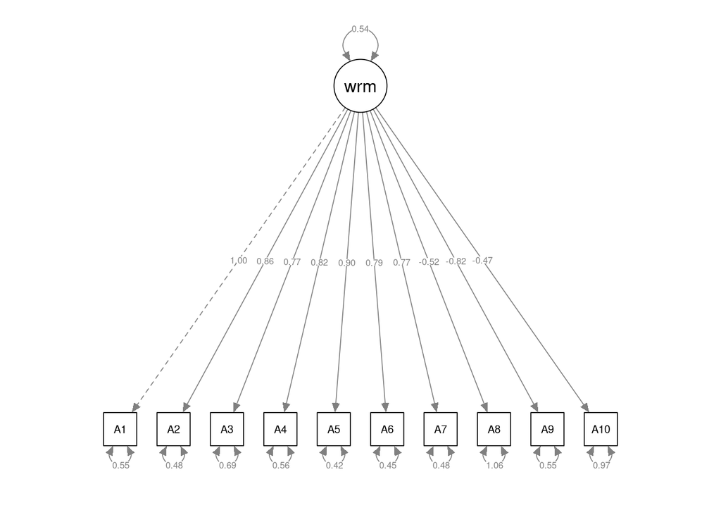

```r
library(semPlot)
semPaths(out1.1, whatLabels = "estimates")
```

Now, we’re going to complicate matters slightly by adding another dimension to our model. We’ll next estimate a two-dimensional CFA that contains correlated “Warmth” and “Dominance” factors.

Define the `lavaan` model syntax for a two-factor model of the *Warmth* and *Dominance* items.

- Save this syntax as an object in your environment.

**Click to show code**

```r
mod2 <- '
warmth    =~ A1 + A2 + A3 + A4 + A5 + A6 + A7 + A8 + A9 + A10
dominance =~ D1 + D2 + D3 + D4 + D5 + D6 + D7 + D8 + D9 + D10
'
```

Estimate the two-factor model, and summarize the results.

- Identify the model by fixing the first factor loading of each construct to 1.
- Do not estimate any mean structure.

**Click to show code**

```r
## Estimate the one factor model:
out2.1 <- cfa(mod2, data = cattell)

## Summarize the results:
summary(out2.1)
```

```
## lavaan 0.6-19 ended normally after 25 iterations
##
##   Estimator                                         ML
##   Optimization method                           NLMINB
##   Number of model parameters                        41
##
##                                                   Used       Total
##   Number of observations                           932        1000
##
## Model Test User Model:
##
##   Test statistic                               823.377
##   Degrees of freedom                               169
##   P-value (Chi-square)                           0.000
##
## Parameter Estimates:
##
##   Standard errors                             Standard
##   Information                                 Expected
##   Information saturated (h1) model          Structured
##
## Latent Variables:
##                    Estimate  Std.Err  z-value  P(>|z|)
##   warmth =~
##     A1                1.000
##     A2                0.867    0.046   18.784    0.000
##     A3                0.772    0.049   15.651    0.000
##     A4                0.813    0.047   17.324    0.000
##     A5                0.905    0.046   19.694    0.000
##     A6                0.794    0.044   18.127    0.000
##     A7                0.768    0.044   17.396    0.000
##     A8               -0.531    0.053  -10.033    0.000
##     A9               -0.822    0.047  -17.566    0.000
##     A10              -0.476    0.050   -9.458    0.000
##   dominance =~
##     D1                1.000
##     D2                0.844    0.042   20.132    0.000
##     D3                0.506    0.041   12.294    0.000
##     D4                0.526    0.041   12.783    0.000
##     D5                0.771    0.033   23.080    0.000
```

[output cut: 20 more lines]

```
##    .A8                1.053    0.050   21.098    0.000
##    .A9                0.544    0.028   19.303    0.000
##    .A10               0.969    0.046   21.160    0.000
##    .D1                0.327    0.023   14.501    0.000
##    .D2                0.684    0.036   19.186    0.000
##    .D3                0.846    0.040   20.898    0.000
##    .D4                0.838    0.040   20.834    0.000
##    .D5                0.368    0.021   17.825    0.000
##    .D6                0.605    0.029   20.767    0.000
##    .D7                0.549    0.030   18.154    0.000
##    .D8                0.730    0.035   21.066    0.000
##    .D9                0.699    0.035   20.183    0.000
##    .D10               1.002    0.049   20.602    0.000
##     warmth            0.543    0.047   11.638    0.000
##     dominance         0.695    0.048   14.518    0.000
```

**Click for explanation**

Use the `semPaths()` function to draw a path diagram of your estimated CFA.

- Include the parameter estimates in the diagram.

**Click to show code**

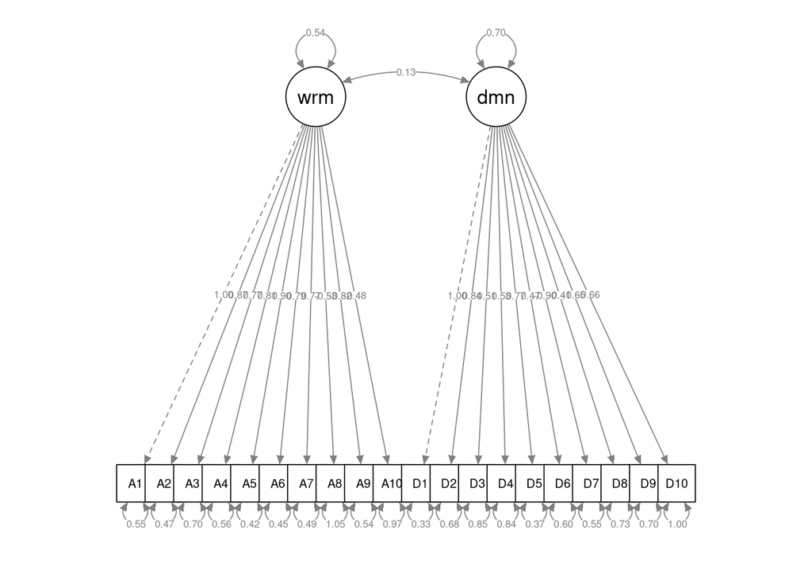

```r
semPaths(out2.1, whatLabels = "estimates")
```

- Add the mean structure.
- Identify the model with the fixed factor method (i.e., standardize the latent variables).

**Click to show code**

```r
out2.2 <- cfa(mod2, data = cattell, meanstructure = TRUE, std.lv = TRUE)
summary(out2.2)
```

```
## lavaan 0.6-19 ended normally after 17 iterations
##
##   Estimator                                         ML
##   Optimization method                           NLMINB
##   Number of model parameters                        61
##
##                                                   Used       Total
##   Number of observations                           932        1000
##
## Model Test User Model:
##
##   Test statistic                               823.377
##   Degrees of freedom                               169
##   P-value (Chi-square)                           0.000
##
## Parameter Estimates:
##
##   Standard errors                             Standard
##   Information                                 Expected
##   Information saturated (h1) model          Structured
##
## Latent Variables:
##                    Estimate  Std.Err  z-value  P(>|z|)
##   warmth =~
##     A1                0.737    0.032   23.276    0.000
##     A2                0.639    0.029   22.266    0.000
##     A3                0.569    0.033   17.483    0.000
##     A4                0.598    0.030   19.926    0.000
##     A5                0.666    0.028   23.856    0.000
##     A6                0.585    0.028   21.184    0.000
##     A7                0.566    0.028   20.037    0.000
##     A8               -0.391    0.037  -10.467    0.000
##     A9               -0.605    0.030  -20.298    0.000
##     A10              -0.350    0.036   -9.819    0.000
##   dominance =~
##     D1                0.834    0.029   29.036    0.000
##     D2                0.703    0.034   20.891    0.000
##     D3                0.422    0.034   12.451    0.000
##     D4                0.439    0.034   12.960    0.000
##     D5                0.643    0.026   24.327    0.000
```

[output cut: 43 more lines]

```
##    .A8                1.053    0.050   21.098    0.000
##    .A9                0.544    0.028   19.303    0.000
##    .A10               0.969    0.046   21.160    0.000
##    .D1                0.327    0.023   14.501    0.000
##    .D2                0.684    0.036   19.186    0.000
##    .D3                0.846    0.040   20.898    0.000
##    .D4                0.838    0.040   20.834    0.000
##    .D5                0.368    0.021   17.825    0.000
##    .D6                0.605    0.029   20.767    0.000
##    .D7                0.549    0.030   18.154    0.000
##    .D8                0.730    0.035   21.066    0.000
##    .D9                0.699    0.035   20.183    0.000
##    .D10               1.002    0.049   20.602    0.000
##     warmth            1.000
##     dominance         1.000
```

End of At-Home Exercises